# Exploratory Data Analysis: Final Project

Jessica Dyer

## Directions

Fine particulate matter (PM2.5) is an ambient air pollutant for which there is strong evidence that it is harmful to human health. In the United States, the Environmental Protection Agency (EPA) is tasked with setting national ambient air quality standards for fine PM and for tracking the emissions of this pollutant into the atmosphere. Approximately every 3 years, the EPA releases its database on emissions of PM2.5. This database is known as the National Emissions Inventory (NEI). You can read more information about the NEI at the EPA National Emissions Inventory web site.

For each year and for each type of PM source, the NEI records how many tons of PM2.5 were emitted from that source over the course of the entire year. The data that you will use for this assignment are for 1999, 2002, 2005, and 2008.

## Assignment

The overall goal of this assignment is to explore the National Emissions Inventory database and see what it say about fine particulate matter pollution in the United states over the 10-year period 1999–2008. You may use any R package you want to support your analysis.

### Questions

You must address the following questions and tasks in your exploratory analysis. For each question/task you will need to make a single plot. Unless specified, you can use any plotting system in R to make your plot.

1. Have total emissions from PM2.5 decreased in the United States from 1999 to 2008? Using the base plotting system, make a plot showing the total PM2.5 emission from all sources for each of the years 1999, 2002, 2005, and 2008.
2. Have total emissions from PM2.5 decreased in the Baltimore City, Maryland (fips == “24510”) from 1999 to 2008? Use the base plotting system to make a plot answering this question.
3. Of the four types of sources indicated by the type (point, nonpoint, onroad, nonroad) variable, which of these four sources have seen decreases in emissions from 1999–2008 for Baltimore City? Which have seen increases in emissions from 1999–2008? Use the ggplot2 plotting system to make a plot answer this question.
4. Across the United States, how have emissions from coal combustion-related sources changed from 1999–2008?
5. How have emissions from motor vehicle sources changed from 1999–2008 in Baltimore City?
6. Compare emissions from motor vehicle sources in Baltimore City with emissions from motor vehicle sources in Los Angeles County, California (fips == “06037”). Which city has seen greater changes over time in motor vehicle emissions?

```r
# Load data from the data_loading.R file
# http://rstudio-pubs-static.s3.amazonaws.com/265497_8211f187ae3b44988c4166db0fb0c345.html
source("data_loading.R")
```

```r
# Examine the NEI dataset
str(NEI)
```

```
## 'data.frame':    6497651 obs. of  6 variables:
##  $ fips     : chr  "09001" "09001" "09001" "09001" ...
##  $ SCC      : chr  "10100401" "10100404" "10100501" "10200401" ...
##  $ Pollutant: chr  "PM25-PRI" "PM25-PRI" "PM25-PRI" "PM25-PRI" ...
##  $ Emissions: num  15.714 234.178 0.128 2.036 0.388 ...
##  $ type     : chr  "POINT" "POINT" "POINT" "POINT" ...
##  $ year     : int  1999 1999 1999 1999 1999 1999 1999 1999 1999 1999 ...
```

```r
# Examine the SCC dataset
str(SCC)
```

```
## 'data.frame':    11717 obs. of  15 variables:
##  $ SCC                : Factor w/ 11717 levels "10100101","10100102",..: 1 2 3 4 5 6 7 8 9 10 ...
##  $ Data.Category      : Factor w/ 6 levels "Biogenic","Event",..: 6 6 6 6 6 6 6 6 6 6 ...
##  $ Short.Name         : Factor w/ 11238 levels "","2,4-D Salts and Esters Prod /Process Vents, 2,4-D Recovery: Filtration",..: 3283 3284 3293 3291 3290 3294 3295 3296 3292 3289 ...
##  $ EI.Sector          : Factor w/ 59 levels "Agriculture - Crops & Livestock Dust",..: 18 18 18 18 18 18 18 18 18 18 ...
##  $ Option.Group       : Factor w/ 25 levels "","C/I Kerosene",..: 1 1 1 1 1 1 1 1 1 1 ...
##  $ Option.Set         : Factor w/ 18 levels "","A","B","B1A",..: 1 1 1 1 1 1 1 1 1 1 ...
##  $ SCC.Level.One      : Factor w/ 17 levels "Brick Kilns",..: 3 3 3 3 3 3 3 3 3 3 ...
##  $ SCC.Level.Two      : Factor w/ 146 levels "","Agricultural Chemicals Production",..: 32 32 32 32 32 32 32 32 32 32 ...
##  $ SCC.Level.Three    : Factor w/ 1061 levels "","100% Biosolids (e.g., sewage sludge, manure, mixtures of these matls)",..: 88 88 156 156 156 156 156 156 156 156 ...
##  $ SCC.Level.Four     : Factor w/ 6084 levels "","(NH4)2 SO4 Acid Bath System and Evaporator",..: 4455 5583 4466 4458 1341 5246 5584 5983 4461 776 ...
##  $ Map.To             : num  NA NA NA NA NA NA NA NA NA NA ...
##  $ Last.Inventory.Year: int  NA NA NA NA NA NA NA NA NA NA ...
##  $ Created_Date       : Factor w/ 57 levels "","1/27/2000 0:00:00",..: 1 1 1 1 1 1 1 1 1 1 ...
##  $ Revised_Date       : Factor w/ 44 levels "","1/27/2000 0:00:00",..: 1 1 1 1 1 1 1 1 1 1 ...
##  $ Usage.Notes        : Factor w/ 21 levels ""," ","includes bleaching towers, washer hoods, filtrate tanks, vacuum pump exhausts",..: 1 1 1 1 1 1 1 1 1 1 ...
```

#### Question 1

1. Have total emissions from PM2.5 decreased in the United States from 1999 to 2008? Using the base plotting system, make a plot showing the total PM2.5 emission from all sources for each of the years 1999, 2002, 2005, and 2008.

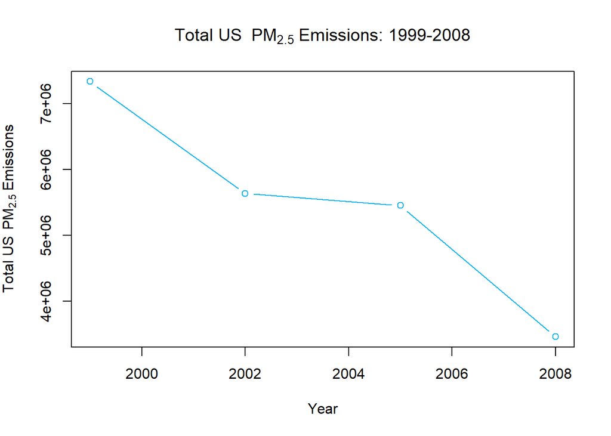

```r
totalNEI <- aggregate(Emissions ~ year, NEI, sum)

plot1 <- plot(totalNEI$year, totalNEI$Emissions, type = "b", col = "deepskyblue2",
     main = expression("Total US "~ PM[2.5]~ "Emissions: 1999-2008"),
     ylab = expression("Total US "~   PM[2.5] ~ "Emissions"),
     xlab = "Year",
     pch = 1)
```

#### Question 2

2. Have total emissions from PM2.5 decreased in the Baltimore City, Maryland (fips == “24510”) from 1999 to 2008? Use the base plotting system to make a plot answering this question.

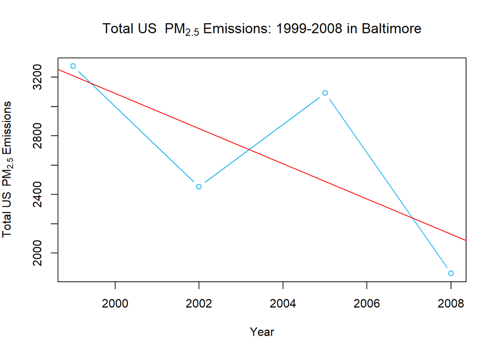

```r
baltimore_df <- filter(NEI, fips == "24510")

baltimore_plot_data <- aggregate(Emissions ~ year, baltimore_df, sum)

plot2 <- plot(baltimore_plot_data$year, baltimore_plot_data$Emissions,
              col = "deepskyblue2", type = "b",
              main = expression("Total US "~ PM[2.5]~ "Emissions: 1999-2008 in Baltimore"),
              ylab = expression("Total US "~   PM[2.5] ~ "Emissions"),
              xlab = "Year",
              pch = 1)
abline(lm(Emissions ~ year, data= baltimore_plot_data), col = "red")
```

#### Question 3

3. Of the four types of sources indicated by the type (point, nonpoint, onroad, nonroad) variable, which of these four sources have seen decreases in emissions from 1999–2008 for Baltimore City? Which have seen increases in emissions from 1999–2008? Use the ggplot2 plotting system to make a plot answer this question.

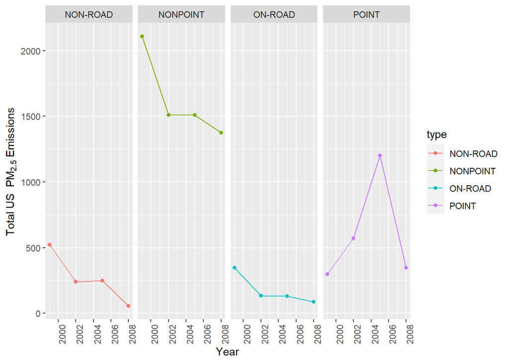

```r
baltimore_plot_data_2 <- aggregate(Emissions ~ year*type, baltimore_df, sum)

plot <- qplot(year, Emissions, data = baltimore_plot_data_2, col = type, facets = .~type, ylab = expression("Total US "~   PM[2.5] ~ "Emissions"), xlab = "Year") + geom_line()

plot + theme(axis.text.x = element_text(angle = 90))
```

#### Question 4

4. Across the United States, how have emissions from coal combustion-related sources changed from 1999–2008?

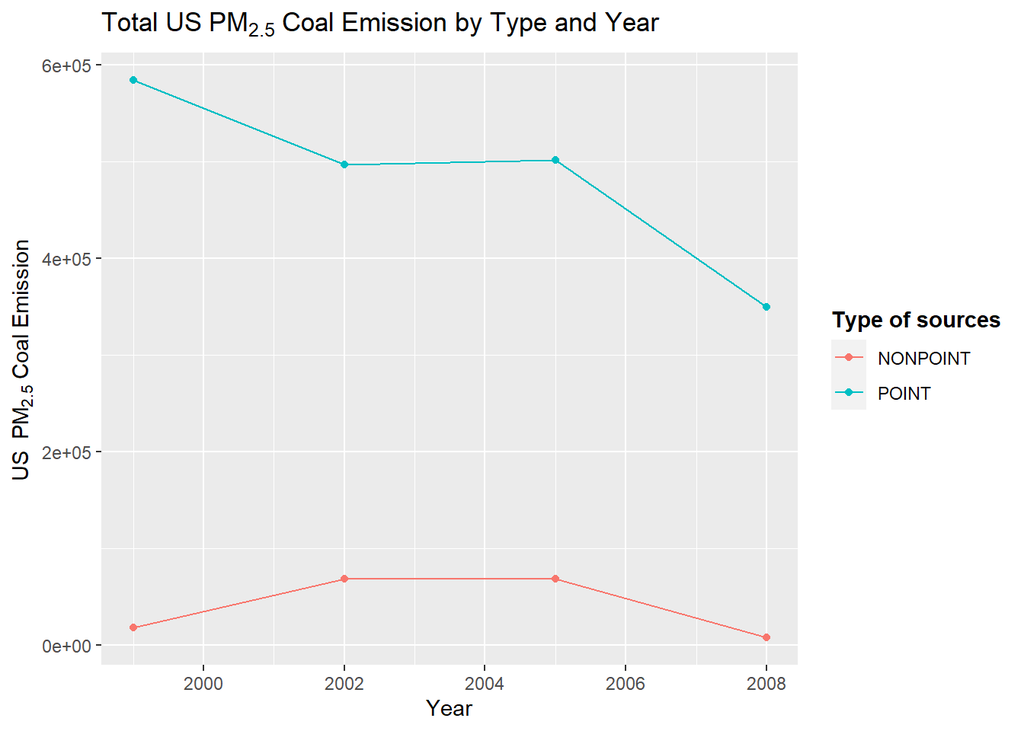

```r
scc_subset <- SCC[grepl("coal",SCC$Short.Name, ignore.case = T), ]
coal_df <- NEI[NEI$SCC %in% scc_subset$SCC, ]

coal_plot_data <- aggregate(Emissions ~ year*type, coal_df, sum)

ggplot(coal_plot_data, aes(year, Emissions, col = type)) +
      geom_line() +
      geom_point() +
      ggtitle(expression("Total US" ~ PM[2.5] ~ "Coal Emission by Type and Year")) +
      xlab("Year") +
      ylab(expression("US " ~ PM[2.5] ~ "Coal Emission")) +
      scale_colour_discrete(name = "Type of sources") +
      theme(legend.title = element_text(face = "bold"))
```

#### Question 5

5. How have emissions from motor vehicle sources changed from 1999–2008 in Baltimore City?
- NEI onroad sources include emissions from onroad vehicles that use gasoline, diesel, and other fuels. These sources include light duty and heavy duty vehicle emissions from operation on roads, highway ramps, and during idling.

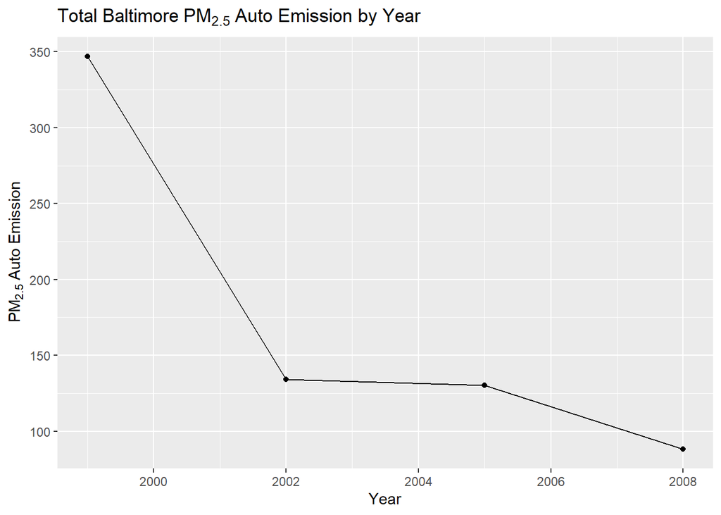

```r
baltimore_auto_df <- filter(NEI, fips == "24510" & type == "ON-ROAD")

baltimore_auto_plot <- aggregate(Emissions ~ year, baltimore_auto_df, sum)

ggplot(baltimore_auto_plot, aes(year, Emissions)) +
      geom_line() +
      geom_point() +
      ggtitle(expression("Total Baltimore" ~ PM[2.5] ~ "Auto Emission by Year")) +
      xlab("Year") +
      ylab(expression(~ PM[2.5] ~ "Auto Emission"))
```

#### Question 6

6. Compare emissions from motor vehicle sources in Baltimore City with emissions from motor vehicle sources in Los Angeles County, California (fips == “06037”). Which city has seen greater changes over time in motor vehicle emissions?

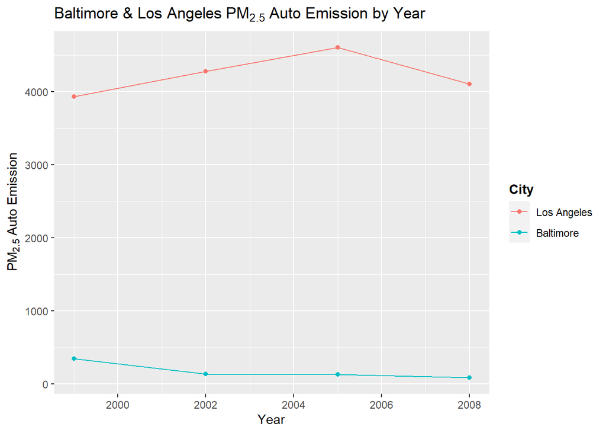

```r
baltimore_la_df <- subset(NEI, NEI$fips %in% c("24510","06037") & NEI$type == "ON-ROAD")

baltimore_la_plot <- aggregate(Emissions ~ year*fips, baltimore_la_df, sum)

ggplot(baltimore_la_plot, aes(year, Emissions, col = fips)) +
      geom_line() +
      geom_point() +
      ggtitle(expression("Baltimore & Los Angeles" ~ PM[2.5] ~ "Auto Emission by Year")) +
      xlab("Year") +
      ylab(expression(~ PM[2.5] ~ "Auto Emission")) +
      scale_colour_discrete(name = "City", labels = c("Los Angeles", "Baltimore")) +
      theme(legend.title = element_text(face = "bold"))
```